# Aprendizagem Não Supervisionada em R

Pedro Almeida

2 de abril de 2019

Muitas vezes no aprendizado de máquina o objetivo é encontrar padrões nos dados sem tentar fazer previsões, isso é chamado de aprendizagem não supervisionada. É comum usar a aprendizagem não supervisionada para agrupar consumidores com base em dados demográficos e histórico de compras para campanhas de marketing direcionadas. Outro exemplo é querer descrever os fatores não medidos que mais influenciam as diferenças entre cidades. Este tutorial é uma introdução básica às técnicas de cluster e redução de dimensionalidade em R a partir de uma perspectiva de aprendizado de máquina.

## 1) k-means

O algoritmo k-means é amplamente usado para realizar a tarefa de cluster nos dados (cluster = “agrupamento” em português). Problemas que demandam realizar clusters são: * Determinar agrupamentos de casas para venda com base no tamanho, número de quartos, etc; * Determinar se há padrões comuns de demografia de pessoas para um segmento do mercado;

Vou usar o dataset “x” no qual possui duas dimensões que usarei para criar um modelo de k-means usando 3 clusters, em seguida examinarei a estrutura do modelo resultante usando a função summary().

```r
# carregando os dados
library(readxl) # pacote necessário para ler o arquivo
x <- read_xlsx("x.xlsx", sheet = 1)

# criando o modelo de k-means: km.out
km.out <- kmeans(x, centers = 3, nstart = 20)

# verificando o modelo
summary(km.out)
```

```
##              Length Class  Mode
## cluster      300    -none- numeric
## centers        6    -none- numeric
## totss          1    -none- numeric
## withinss       3    -none- numeric
## tot.withinss   1    -none- numeric
## betweenss      1    -none- numeric
## size           3    -none- numeric
## iter           1    -none- numeric
## ifault         1    -none- numeric
```

A função kmeans() produz várias saídas. A seguir, acessarei a componente do cluster diretamente. Isso é útil sempre que você precisar da associação de cluster para cada observação dos dados usados para construir o modelo de armazenamento em cluster. Mais adiante mostrarei um exemplo de como essa associação de cluster pode ser usada para ajudar a comunicar os resultados da modelagem k-means.

Nos modelos k-means é possível visualizarmos os resultados da modelagem usando a função print() ou simplesmente digitando o nome do modelo.

```r
# visualizando a componente de cluster
km.out$cluster
```

```
##   [1] 1 1 1 1 1 1 1 1 1 1 1 1 2 1 1 1 1 2 2 1 1 1 1 1 1 1 1 1 1 1 1 1 1 1 1
##  [36] 1 2 2 2 1 1 1 1 2 1 1 1 1 1 1 1 1 1 1 1 1 1 1 2 1 1 1 1 1 1 1 1 1 1 1
##  [71] 1 1 1 2 1 1 1 1 1 1 1 1 1 1 1 1 1 1 1 1 1 1 1 1 1 1 1 1 1 1 3 3 3 3 3
## [106] 3 3 3 3 3 3 3 3 3 3 3 3 3 3 3 3 3 3 3 3 3 3 3 3 3 3 3 3 3 3 3 3 3 3 3
## [141] 3 3 3 3 3 3 3 3 3 3 3 3 3 3 3 3 3 3 3 3 3 3 3 3 3 3 3 3 3 3 3 3 3 3 3
## [176] 3 3 3 3 3 3 3 3 3 3 3 3 3 3 3 3 3 3 3 3 3 3 3 3 3 3 3 3 3 3 3 3 3 3 3
## [211] 3 3 3 3 3 3 3 3 3 3 3 3 3 3 3 3 3 3 3 3 3 3 3 3 3 3 3 3 3 3 3 3 3 3 3
## [246] 3 3 3 3 3 2 2 2 2 1 2 2 2 2 2 2 2 2 2 2 2 2 2 2 2 2 2 2 2 2 1 1 2 2 1
## [281] 2 2 2 2 2 2 1 2 2 2 2 2 2 1 2 2 2 1 2 2
```

```r
# visualizando a saída do modelo
km.out
```

```
## K-means clustering with 3 clusters of sizes 98, 52, 150
##
## Cluster means:
##            x           y
## 1  2.2170408  2.05153061
## 2  0.6642308 -0.09115385
## 3 -5.0554667  1.96973333
##
## Clustering vector:
##   [1] 1 1 1 1 1 1 1 1 1 1 1 1 2 1 1 1 1 2 2 1 1 1 1 1 1 1 1 1 1 1 1 1 1 1 1
##  [36] 1 2 2 2 1 1 1 1 2 1 1 1 1 1 1 1 1 1 1 1 1 1 1 2 1 1 1 1 1 1 1 1 1 1 1
##  [71] 1 1 1 2 1 1 1 1 1 1 1 1 1 1 1 1 1 1 1 1 1 1 1 1 1 1 1 1 1 1 3 3 3 3 3
## [106] 3 3 3 3 3 3 3 3 3 3 3 3 3 3 3 3 3 3 3 3 3 3 3 3 3 3 3 3 3 3 3 3 3 3 3
## [141] 3 3 3 3 3 3 3 3 3 3 3 3 3 3 3 3 3 3 3 3 3 3 3 3 3 3 3 3 3 3 3 3 3 3 3
## [176] 3 3 3 3 3 3 3 3 3 3 3 3 3 3 3 3 3 3 3 3 3 3 3 3 3 3 3 3 3 3 3 3 3 3 3
## [211] 3 3 3 3 3 3 3 3 3 3 3 3 3 3 3 3 3 3 3 3 3 3 3 3 3 3 3 3 3 3 3 3 3 3 3
## [246] 3 3 3 3 3 2 2 2 2 1 2 2 2 2 2 2 2 2 2 2 2 2 2 2 2 2 2 2 2 2 1 1 2 2 1
## [281] 2 2 2 2 2 2 1 2 2 2 2 2 2 1 2 2 2 1 2 2
##
## Within cluster sum of squares by cluster:
## [1] 148.7013  95.4708 295.1237
##  (between_SS / total_SS =  87.2 %)
##
## Available components:
##
## [1] "cluster"      "centers"      "totss"        "withinss"
## [5] "tot.withinss" "betweenss"    "size"         "iter"
## [9] "ifault"
```

### 1.1) Visualizando clusters

Uma das maneiras mais intuitivas de interpretar os resultados dos modelos k-means é plotando os dados como um gráfico de dispersão e usando cores para rotular a associação de cluster das amostras. Vou usar a função plot() padrão para realizar isso.

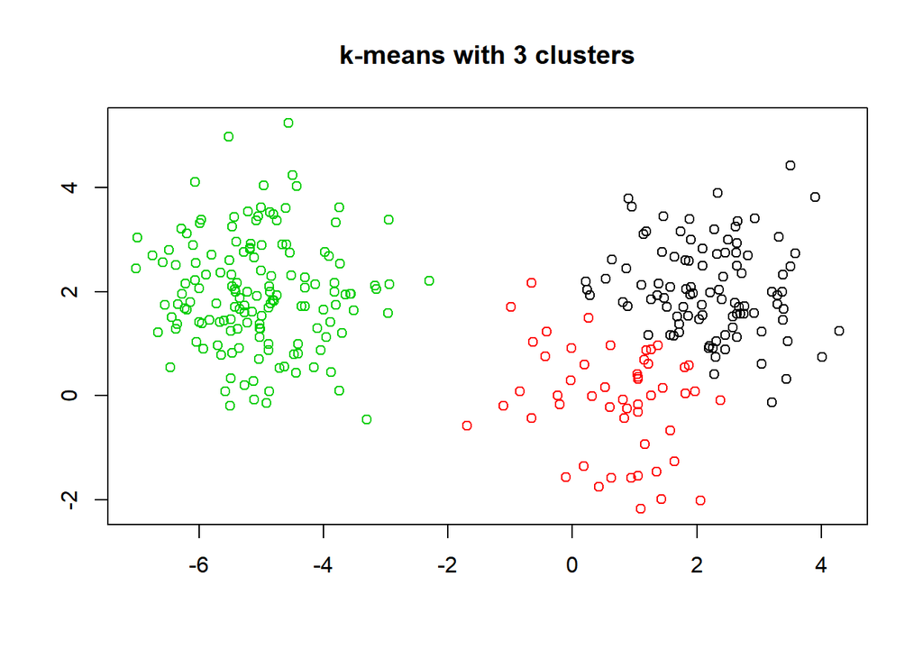

```r
# gráfico de dispersão x
plot(x, col = km.out$cluster,
     main = "k-means with 3 clusters",
     xlab = "", ylab = "")
```

### 1.2) Aleatoriedade do algoritmo k-means

A função kmeans() gera aleatoriamente os centros de clusters, essa aleatoriedade pode resultar em diferentes cluster a cada vez que executar o modelo. Além disso, essa geração aleatória pode resultar em diferentes locais mínimos para o algoritmo k-means. A seguir vou demonstrar os dois resultados.

No topo de cada gráfico, a medida da qualidade do modelo será plotada, assim podemos ver os modelos com os melhores resultados.

Como o kmeans() gera as observações para clusters aleatoriamente, é importante definir o gerador de números aleatórios para podermos reproduzir o resultado do modelo.

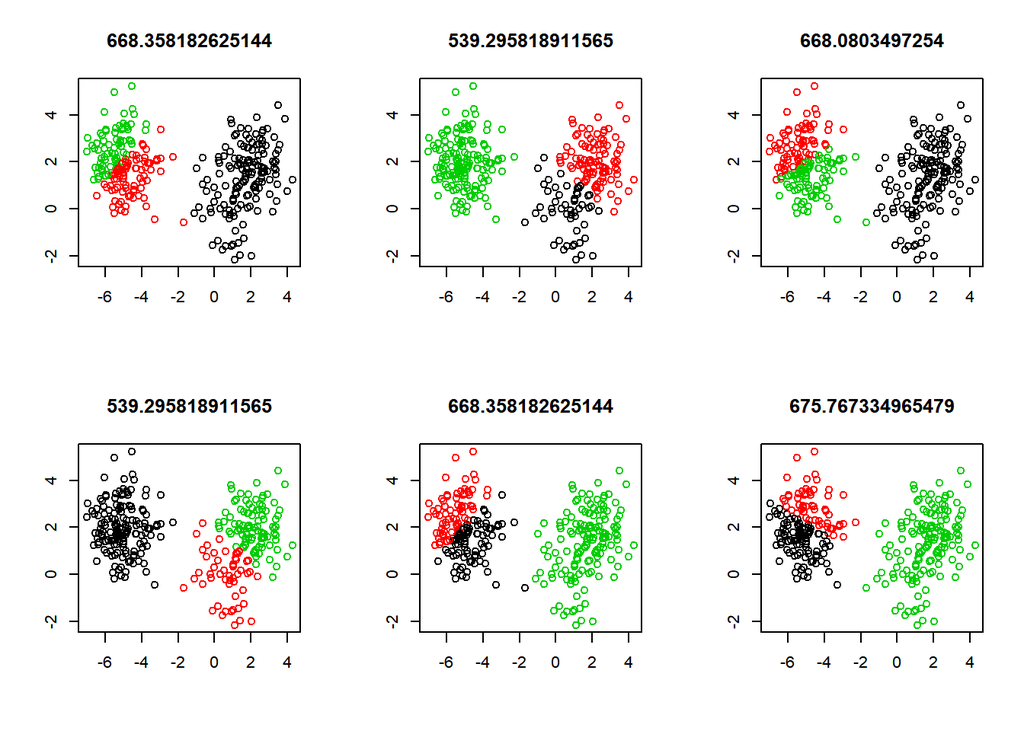

```r
# configurando a grade de 2x3
par(mfrow = c(2, 3))

# para reprodução dos resultados do modelo
set.seed(1)

for(i in 1:6) {
  # rodando o kmeans() com 3 clusters 1 começo
  km.out <- kmeans(x, centers = 3, nstart = 1)
  # visualizando os clusters
  plot(x, col = km.out$cluster,
       main = km.out$tot.withinss,
       xlab = "", ylab = "")
}
```

Por conta da geração aleatória do algoritmo k-means, há bastante variação entre as métricas de qualidade do cluster entre os seis modelos.

### 1.3) Selecionando o número de clusters

O algoritmo k-means assume o número de clusters como parte do input. Se você souber antecipadamente o número de clusters (por exemplo, devido a certas características do negócio), isso facilita a configuração do número de clusters. No entanto, se não souber o número de clusters e precisar determiná-lo, será necessário executar o algoritmo várias vezes, cada vez com um número diferente de clusters. A partir disso, você pode observar como a métrica da qualidade do modelo muda com o número de clusters.

A seguir vou executar o kmeans() várias vezes para ver como a qualidade do modelo é alterada conforme o número de clusters é alterado. Os gráficos que exibem essas informações ajudam a determinar o número de clusters e são geralmente chamados de scree plot.

O ideal é visualizar um cotovelo onde a métrica de qualidade melhora mais lentamente à medida que o número de agrupamentos aumenta. Isso indica que a qualidade do modelo não está mais melhorando substancialmente à medida que a complexidade do modelo (ou seja, o número de clusters) aumenta. Em outras palavras, o cotovelo indica o número de clusters inerentes aos dados.

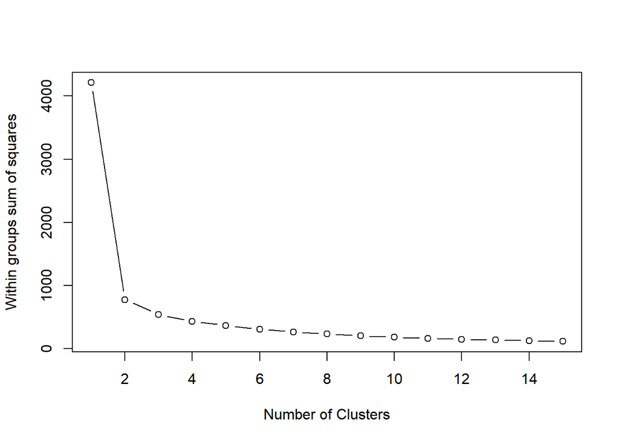

```r
# começando com a soma total dos erros ao quadrado: wss
wss <- 0

# de 1 a 15 centros de cluster
for (i in 1:15) {
  km.out <- kmeans(x, centers = i, nstart = 20)
  # salvando a soma total dos quadrados no objeto wss
  wss[i] <- km.out$tot.withinss
}

# visualizando a soma total dos quadrados X o número de clusters
plot(1:15, wss, type = "b",
     xlab = "Number of Clusters",
     ylab = "Within groups sum of squares")
```

```r
# configurando o k
k <- 2  # 3 também seria ok
```

Olhando para o scree plot parece que existem 2 ou 3 clusters nos dados.

### 1.4) Trabalhando com dados reais

Lidar com dados reais costuma ser mais desafiador do que lidar com dados sintéticos. Os dados sintéticos ajudam a aprender novos conceitos e técnicas, mas a seguir vamos lidar com dados mais reais, no qual podemos encontrar em nossas atividades profissionais ou acadêmicas.

Usarei aqui os dados do Pokemon disponível no site do kaggle. O primeiro desafio com os dados do Pokemon é que não há um número pré-determinado de clusters. Você determinará o número apropriado de grupos, tendo em mente que, em dados reais, o cotovelo do scree plot pode ser saliente do que em dados sintéticos. Use seu julgamento para determinar o número de clusters se quiser.

Uma observação adicional: este exercício utiliza o argumento iter.max para kmeans(). Como você viu, kmeans() é um algoritmo iterativo, repetindo várias vezes até que algum critério de parada seja atingido. O número padrão de iterações para kmeans() é 10, o que não é suficiente para o algoritmo convergir e atingir seu critério de parada, portanto, definiremos o número de iterações como 50 para superar esse problema. Para ver o que acontece quando o kmeans() não converge, tente executar o exemplo com um número menor de iterações (por exemplo, 3). Este é outro exemplo do que pode acontecer quando você trabalha com dados reais.

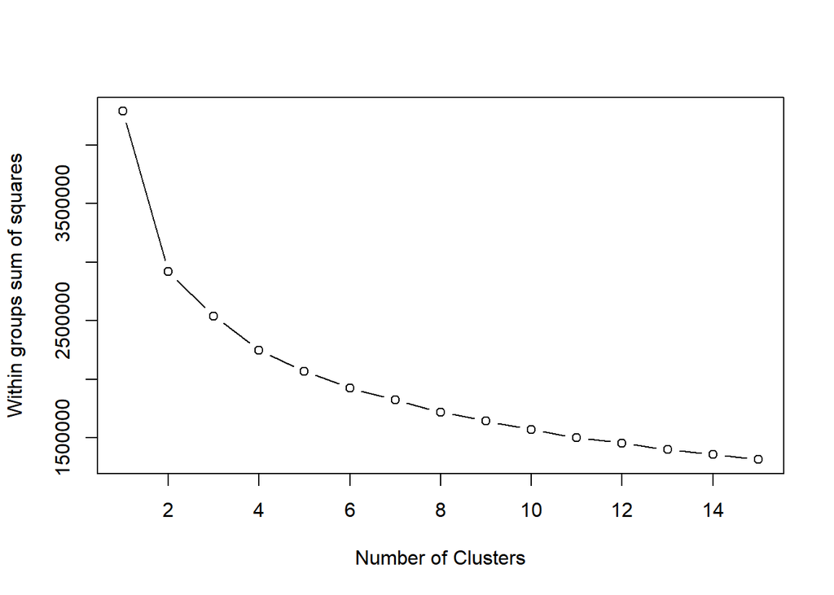

```r
# importando os dados do pokemon
pokemon <- read.csv("Pokemon.csv", sep = ",")
pokemon <- pokemon[,6:11]

# começando com a soma total dos erros ao quadrado: wss
wss <- 0

# de 1 a 15 centros de cluster
for (i in 1:15) {
  km.pokemon <- kmeans(pokemon, centers = i, nstart = 20, iter.max = 50)
  # salvando a soma total dos quadrados no objeto wss
  wss[i] <- km.pokemon$tot.withinss
}

# visualizando a soma total dos quadrados X o número de clusters
plot(1:15, wss, type = "b",
     xlab = "Number of Clusters",
     ylab = "Within groups sum of squares")
```

```r
# selecionando o número de clusters (pode ser 2, 3 ou 4...)
k <- 3

# construindo o modelo com k clusters: km.out
km.pokemon <- kmeans(pokemon, centers = k, nstart = 20, iter.max = 50)

# visualizando os resultados do modelo
km.pokemon
```

```
## K-means clustering with 3 clusters of sizes 353, 177, 270
##
## Cluster means:
##   HitPoints   Attack   Defense SpecialAttack SpecialDefense    Speed
## 1  54.62890 56.99433  53.38810      52.02833       52.87252 53.66572
## 2  79.14689 96.71751 108.81921      66.53672       87.01130 57.09605
## 3  81.90370 96.15926  77.65556     104.12222       86.87778 94.71111
##
## Clustering vector:
##   [1] 1 1 3 3 1 1 3 3 3 1 1 2 3 1 1 1 1 1 1 3 1 1 3 3 1 1 1 3 1 3 1 3 1 2 1
##  [36] 1 2 1 1 3 1 3 1 3 1 1 1 3 1 1 3 1 2 1 3 1 1 1 3 1 3 1 3 1 3 1 1 2 1 3
##  [71] 3 3 1 2 2 1 1 3 1 3 1 2 2 1 3 1 2 2 1 3 1 1 3 1 2 1 2 1 2 1 3 3 3 2 1
## [106] 2 1 2 1 3 1 3 1 2 2 2 1 1 2 1 2 1 2 2 2 1 3 1 2 1 3 3 3 3 3 3 2 2 2 1
## [141] 2 2 2 1 1 3 3 3 1 1 2 1 2 3 3 2 3 3 3 1 1 3 3 3 3 3 1 1 2 1 1 3 1 1 2
## [176] 1 1 1 3 1 1 1 1 3 1 3 1 1 1 1 1 1 3 1 1 3 3 2 1 2 2 3 1 1 3 1 1 1 1 1
```

[output cut: 27 more lines]

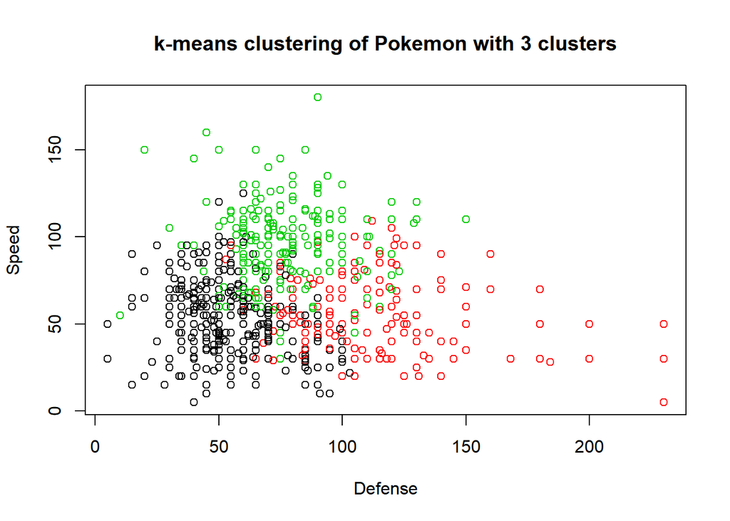

```r
# visualizando os clusters de defesa X velocidade
plot(pokemon[, c("Defense", "Speed")],
     col = km.pokemon$cluster,
     main = paste("k-means clustering of Pokemon with", k, "clusters"),
     xlab = "Defense",
     ylab = "Speed")
```

## 2) Clustering hierárquico

O clustering hierárquico é outro método popular de clustering. O objetivo deste capítulo é mostrar como ele funciona, como usá-lo e como ele se compara ao k-means.

### 2.1) Modelo simples de clustering hierárquico

A seguir vou criar o nosso primeiro modelo de clustering hierárquico usando a função hclust(). Usarei o dataset “z” para criar um modelo de clustering hierárquico. O primeiro passo para o modelo de clustering hierárquico é determinar a similaridade entre observações, usando a função dist(). Ao final vou examinar a estrutura do modelo resultante usando a função summary().

```r
# carregadno o dataset z
z <- read_xlsx("z.xlsx", sheet = 1)

# criando o modelo de clustering hierárquico
hclust.out <- hclust(dist(z))

# verificando os resultados
summary(hclust.out)
```

```
##             Length Class  Mode
## merge       96     -none- numeric
## height      48     -none- numeric
## order       49     -none- numeric
## labels       0     -none- NULL
## method       1     -none- character
## call         2     -none- call
## dist.method  1     -none- character
```

Agora que criamos nosso primeiro modelo de clustering hierárquico, vamos aprender como usá-lo para resolver problemas.

### 2.2) Podando a árvore

Usaremos a função cutree() que corta horizontalmente o modelo hierárquico. Os argumentos h e k do cutree() permitem cortar a árvore com base em uma certa altura h ou com um determinado número de clusters k. A seguir vou usar o cutree() para cortar o modelo hierárquico criado anteriormente com base em cada um desses dois critérios.

```r
# podando pela altura
cutree(hclust.out, h = 7)
```

```
##  [1] 1 1 1 1 1 1 1 2 1 1 1 1 1 1 1 1 1 1 1 1 1 1 1 1 2 2 2 2 2 2 2 2 2 2 1
## [36] 1 1 1 1 1 2 1 1 1 1 1 1 1 1
```

```r
# podando pelo número de clusters
cutree(hclust.out, k = 3)
```

```
##  [1] 1 1 1 1 1 1 1 2 1 1 1 1 1 1 1 1 3 3 1 1 1 1 1 1 2 2 2 2 2 2 2 2 2 2 3
## [36] 1 1 1 3 3 2 3 3 3 3 3 3 1 3
```

### 2.3) Métodos de ligação

Agora vou explorar modelos de clustering hierárquico usando diferentes métodos de ligação e vou plotar o dendrograma de cada um, para observarmos a estrutura geral das árvores.

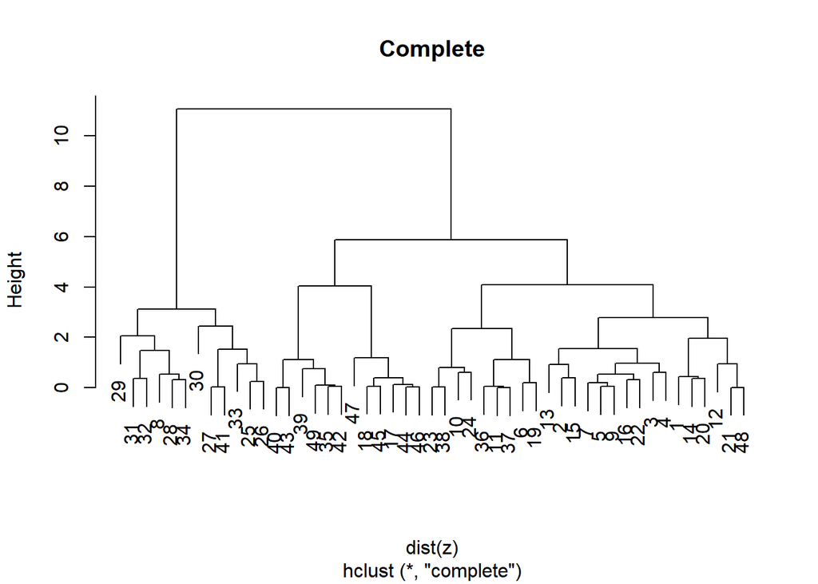

```r
# cluster usando a ligação "complete"
hclust.complete <- hclust(dist(z), method = "complete")

# cluster usando a ligação "average"
hclust.average <- hclust(dist(z), method = "average")

# cluster usando a ligação "single"
hclust.single <- hclust(dist(z), method = "single")

# plotando o dendograma que usa a ligação "complete"
plot(hclust.complete, main = "Complete")
```

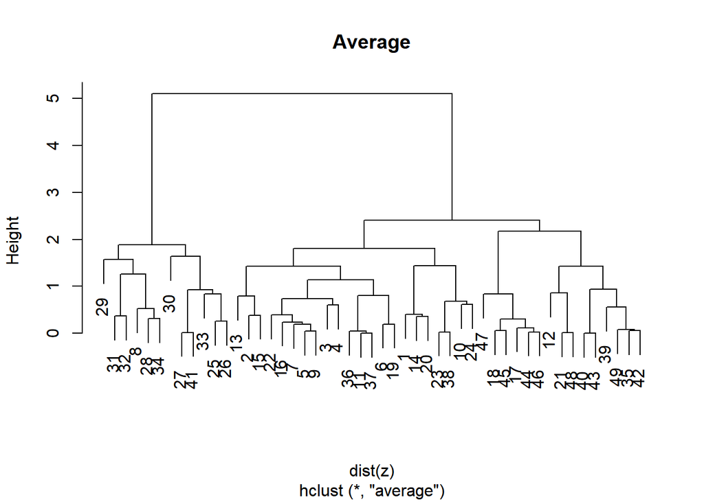

```r
# plotando o dendograma que usa a ligação "average"
plot(hclust.average, main = "Average")
```

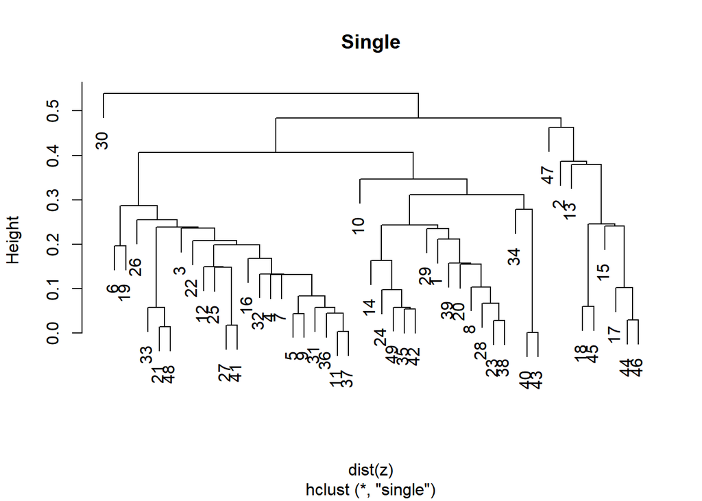

```r
# plotando o dendograma que usa a ligação "single"
plot(hclust.single, main = "Single")
```

Antes de continuarmos, verifique os gráficos para comparar os três dendrogramas, vou explicar a seguir sobre as implicações dessas diferenças!

É visível que as ligações “complete” e “average” produzem clusters mais equilibrados. Ter árvores balanceadas ou não balanceadas para seu modelo hierárquico de clustering, vai depender do contexto do problema que você está tentando resolver. Árvores equilibradas são essenciais se você quer um número par de observações atribuídas a cada cluster. Por outro lado, se você quiser detectar valores discrepantes por exemplo, uma árvore desequilibrada é mais adequada porque a remoção de uma árvore não balanceada pode resultar na maioria das observações atribuídas a um cluster, e apenas algumas observações atribuídas a outros clusters.

### 2.3) Questões práticas: dimensionamento

Lembre-se de que os dados reais em cluster podem exigir o dimensionamento dos recursos se eles tiverem distribuições diferentes. Até agora, trabalhei com dados sintéticos que não precisam de escalonamento.

A seguir voltarei a trabalhar com dados reais, usarei o dataset pokemon novamente. Vamos observar a distribuição (média e desvio padrão) de cada recurso, dimensionar os dados de acordo, e em seguida produzir um modelo de agrupamento hierárquico usando o método de ligação completo.

```r
# verificando o nome das colunas do dataset
colMeans(pokemon)
```

```
##      HitPoints         Attack        Defense  SpecialAttack SpecialDefense
##       69.25875       79.00125       73.84250       72.82000       71.90250
##          Speed
##       68.27750
```

```r
# verificando o desvio padrão das compenentes do dataset
apply(pokemon, 2, sd)
```

```
##      HitPoints         Attack        Defense  SpecialAttack SpecialDefense
##       25.53467       32.45737       31.18350       32.72229       27.82892
##          Speed
##       29.06047
```

```r
# escalonando os dados
pokemon.scaled <- scale(pokemon)

# criando o modelo de clustering hierárquico
hclust.pokemon <- hclust(dist(pokemon.scaled), method = "complete")
```

Vamos rapidamente recapitular o que acabei de fazer: 1) Verifiquei primeiro se as médias das colunas e os desvios padrão variam; 2) Por causa disso, escalei os dados; 3) Converti os dados escalados para uma matriz de similaridade e as passei para a função hclust()

### 2.4) Comparando kmeans() e hclust()

Agora vou comparar o k-means e o clustering hierárquico, vamos ver como esses dois métodos produzem diferentes associações de cluster. Isso ocorre porque os dois algoritmos fazem suposições diferentes sobre como os dados são gerados. A seguir vou comparar os resultados dos dois modelos do dataset pokemon para ver como eles são diferentes.

```r
# aplicando a função cutree() no hclust.pokemon
cut.pokemon <- cutree(hclust.pokemon, k = 3)

# comparando os métodos
table(km.pokemon$cluster, cut.pokemon)
```

```
##    cut.pokemon
##       1   2   3
##   1 348   5   0
##   2 173   3   1
##   3 267   3   0
```

Olhando para a tabela, parece que o modelo hierárquico de clustering atribui a maioria das observações ao cluster 1, enquanto o algoritmo k-means distribui as observações de forma relativamente uniforme entre todos os clusters. É importante notar que não há consenso sobre qual método produz melhores clusters. O trabalho do analista para o clustering não supervisionado é observar as atribuições do cluster e fazer uma avaliação de quanto cada método fornece mais insights sobre os dados!

# Código em construção ;*